# Who Would Survive the Titanic Diaster?

Lanqin Zhao

### Who Would Survive the Titanic Disaster?

This project is from https://www.kaggle.com/c/titanic

“The sinking of the RMS Titanic is one of the most infamous shipwrecks in history. On April 15, 1912, during her maiden voyage, the Titanic sank after colliding with an iceberg, killing 1502 out of 2224 passengers and crew. This sensational tragedy shocked the international community and led to better safety regulations for ships.

One of the reasons that the shipwreck led to such loss of life was that there were not enough lifeboats for the passengers and crew. Although there was some element of luck involved in surviving the sinking, some groups of people were more likely to survive than others, such as women, children, and the upper-class.

In this challenge, we ask you to complete the analysis of what sorts of people were likely to survive. In particular, we ask you to apply the tools of machine learning to predict which passengers survived the tragedy."

## Step 1 - Collecting data —-

The data is from https://www.kaggle.com/c/titanic/data

The data has been split into two groups: training set (train.csv) test set (test.csv) Traing set includes 891 examples, 12 variables: a label variable, survival indicating whether or not survival, and 11 features.Test set includes 418 examples, 11 features. The 12 variables are discribed as following:

Variable Definition Key survival Survival 0 = No, 1 = Yes pclass Ticket class 1 = 1st, 2 = 2nd, 3 = 3rd sex Sex Age Age in years  
sibsp # of siblings / spouses aboard the Titanic  
parch # of parents / children aboard the Titanic  
ticket Ticket number  
fare Passenger fare  
cabin Cabin number  
embarked Port of Embarkation C = Cherbourg, Q = Queenstown, S = Southampton Variable Notes

pclass: A proxy for socio-economic status (SES) 1st = Upper 2nd = Middle 3rd = Lower

age: Age is fractional if less than 1. If the age is estimated, is it in the form of xx.5

sibsp: The dataset defines family relations in this way… Sibling = brother, sister, stepbrother, stepsister Spouse = husband, wife (mistresses and fiancés were ignored)

parch: The dataset defines family relations in this way… Parent = mother, father Child = daughter, son, stepdaughter, stepson Some children travelled only with a nanny, therefore parch=0 for them.

## Step 2: Exploring and preparing the data—-

Explore the data to understand data, to clean data, to create new festures, to obtain insights, to find predictive features, and prepare the data for modeling.

# Import data

Import the data into R

```r
# load R packages
library(plyr)  # data manipulation
library(dplyr)  # data manipulation
library(ggplot2) # data visiualization
library(scales) # data visiualization
library(gmodels) # crosstable
library(stringr) # String manipulation
library(caret) # tune parameters
library(rpart) # Decision tree utils
library(randomForest) # Random Forest
library(kernlab) # SVM
library(party) # Conditional inference trees
library(gbm) # gbm
library(MASS) # glm
library(fastAdaboost) # AdaBoost
library(xgboost) #xgboost
#Import the CSV file.
train <- read.csv("train.csv", header = TRUE, stringsAsFactors =FALSE)
test <- read.csv("test.csv", header = TRUE,stringsAsFactors =FALSE)
str(train)
```

```
'data.frame':   891 obs. of  12 variables:
 $ PassengerId: int  1 2 3 4 5 6 7 8 9 10 ...
 $ Survived   : int  0 1 1 1 0 0 0 0 1 1 ...
 $ Pclass     : int  3 1 3 1 3 3 1 3 3 2 ...
 $ Name       : chr  "Braund, Mr. Owen Harris" "Cumings, Mrs. John Bradley (Florence Briggs Thayer)" "Heikkinen, Miss. Laina" "Futrelle, Mrs. Jacques Heath (Lily May Peel)" ...
 $ Sex        : chr  "male" "female" "female" "female" ...
 $ Age        : num  22 38 26 35 35 NA 54 2 27 14 ...
 $ SibSp      : int  1 1 0 1 0 0 0 3 0 1 ...
 $ Parch      : int  0 0 0 0 0 0 0 1 2 0 ...
 $ Ticket     : chr  "A/5 21171" "PC 17599" "STON/O2. 3101282" "113803" ...
 $ Fare       : num  7.25 71.28 7.92 53.1 8.05 ...
 $ Cabin      : chr  "" "C85" "" "C123" ...
 $ Embarked   : chr  "S" "C" "S" "S" ...
```

```r
str(test)
```

```
'data.frame':   418 obs. of  11 variables:
 $ PassengerId: int  892 893 894 895 896 897 898 899 900 901 ...
 $ Pclass     : int  3 3 2 3 3 3 3 2 3 3 ...
 $ Name       : chr  "Kelly, Mr. James" "Wilkes, Mrs. James (Ellen Needs)" "Myles, Mr. Thomas Francis" "Wirz, Mr. Albert" ...
 $ Sex        : chr  "male" "female" "male" "male" ...
 $ Age        : num  34.5 47 62 27 22 14 30 26 18 21 ...
 $ SibSp      : int  0 1 0 0 1 0 0 1 0 2 ...
 $ Parch      : int  0 0 0 0 1 0 0 1 0 0 ...
 $ Ticket     : chr  "330911" "363272" "240276" "315154" ...
 $ Fare       : num  7.83 7 9.69 8.66 12.29 ...
 $ Cabin      : chr  "" "" "" "" ...
 $ Embarked   : chr  "Q" "S" "Q" "S" ...
```

# Combine data sets and convert data type

```r
# Add a "Survived" variable to the test set to allow for combining data sets
test$Survived <- NA
# Combine data sets
data <- rbind(train, test)
# Convert data type to factor
data$Survived <- as.factor(data$Survived)
data$Pclass <- as.factor(data$Pclass)
data$Sex <- as.factor(data$Sex)
data$Embarked <- as.factor(data$Embarked)
```

# Data understanding

Age has a lot of missing values. Fare and Embarked have a few missing values.There seem no outliers for all features.

```r
summary(data)
```

```
  PassengerId   Survived   Pclass      Name               Sex           Age            SibSp
 Min.   :   1   0   :549   1:323   Length:1309        female:466   Min.   : 0.17   Min.   :0.0000
 1st Qu.: 328   1   :342   2:277   Class :character   male  :843   1st Qu.:21.00   1st Qu.:0.0000
 Median : 655   NA's:418   3:709   Mode  :character                Median :28.00   Median :0.0000
 Mean   : 655                                                      Mean   :29.88   Mean   :0.4989
 3rd Qu.: 982                                                      3rd Qu.:39.00   3rd Qu.:1.0000
 Max.   :1309                                                      Max.   :80.00   Max.   :8.0000
                                                                   NA's   :263
     Parch          Ticket               Fare            Cabin           Embarked
 Min.   :0.000   Length:1309        Min.   :  0.000   Length:1309         :  2
 1st Qu.:0.000   Class :character   1st Qu.:  7.896   Class :character   C:270
 Median :0.000   Mode  :character   Median : 14.454   Mode  :character   Q:123
 Mean   :0.385                      Mean   : 33.295                      S:914
 3rd Qu.:0.000                      3rd Qu.: 31.275
 Max.   :9.000                      Max.   :512.329
                                    NA's   :1
```

# Data exploration, data cleaning, data manipulation, and feature engineering

Survived: the survival rate was 38.4%.

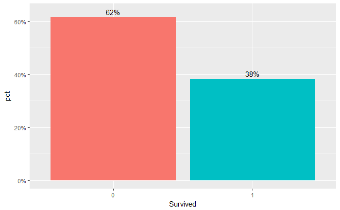

```r
# Survival rate
data[1:891,] %>%
  group_by(Survived) %>%
  summarise(count=n()) %>%
  mutate(pct=count/sum(count))  %>%
  ggplot(aes(x=Survived, y=pct, fill=Survived)) +
  geom_bar(stat="identity") +
  scale_y_continuous(labels=percent) +
  geom_text(aes(label=paste0(round(pct*100,0),"%"), y=pct+0.02), size=4, colour= "black")+
  theme(legend.position = "NULL")
```

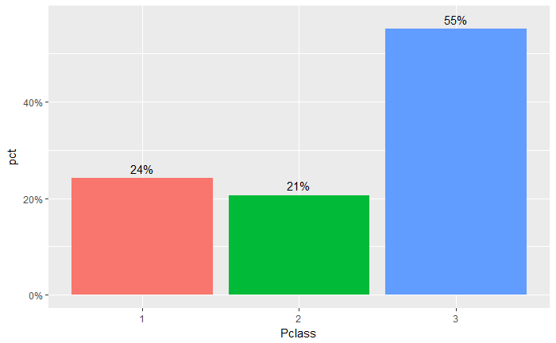

```r
# Pclass
data[1:891,] %>%
  group_by(Pclass) %>%
  summarise(count=n()) %>%
  mutate(pct=count/sum(count))  %>%
  ggplot(aes(x=Pclass, y=pct, fill=Pclass)) +
  geom_bar(stat="identity") +
  scale_y_continuous(labels=percent) +
  geom_text(aes(label=paste0(round(pct*100,0),"%"), y=pct+0.02), size=4, colour= "black")+
  theme(legend.position = "none")
```

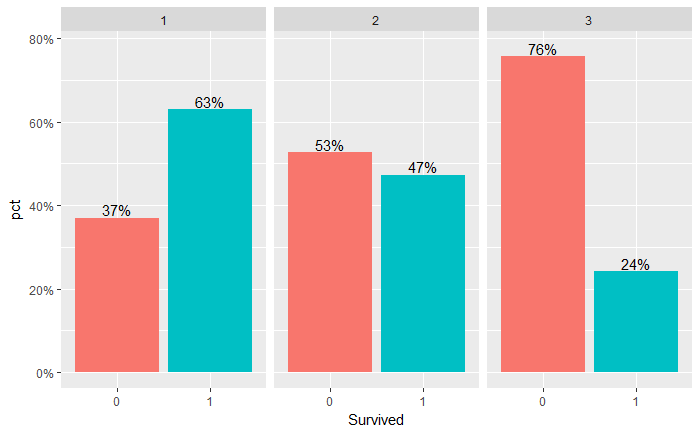

```r
#Pclass VS Survival Rate
data[1:891,] %>% group_by(Pclass, Survived) %>%
  summarise(count=n()) %>%
  mutate(pct=count/sum(count))  %>%
ggplot(aes(x=Survived, y=pct, fill=Survived)) +
  geom_bar(stat="identity") +
  facet_grid(. ~ Pclass) +
  scale_y_continuous(labels=percent) +
  geom_text(aes(label=paste0(round(pct*100,0),"%"), y=pct+0.02), size=4, colour= "black")+
  theme(legend.position = "none")
```

Name: contains formal titles, which can be extracted as a potentially useful feature. Ttile, new variable derived by Name. Baesd on the plots, 60% off passengers were Mr; “Women and children first” is true in Tatanic diaster. Women and children had more than 3 times that men had to survive;It’s obvious that Title and Pclass play important roles in predicting who would survive. Passengers having title of Master, Miss, and Mrs had more than 90% chance to survive in first and second class, but those in third class had less han 50% chance. Mr even had less than 40% chance to survive in first class and about 10% in second and third class.

```r
#Name: new variable Title derived by Name is predictive
# Look at the first few names
data$Name[1:20]
```

```
 [1] "Braund, Mr. Owen Harris"
 [2] "Cumings, Mrs. John Bradley (Florence Briggs Thayer)"
 [3] "Heikkinen, Miss. Laina"
 [4] "Futrelle, Mrs. Jacques Heath (Lily May Peel)"
 [5] "Allen, Mr. William Henry"
 [6] "Moran, Mr. James"
 [7] "McCarthy, Mr. Timothy J"
 [8] "Palsson, Master. Gosta Leonard"
 [9] "Johnson, Mrs. Oscar W (Elisabeth Vilhelmina Berg)"
[10] "Nasser, Mrs. Nicholas (Adele Achem)"
[11] "Sandstrom, Miss. Marguerite Rut"
[12] "Bonnell, Miss. Elizabeth"
[13] "Saundercock, Mr. William Henry"
[14] "Andersson, Mr. Anders Johan"
[15] "Vestrom, Miss. Hulda Amanda Adolfina"
[16] "Hewlett, Mrs. (Mary D Kingcome) "
[17] "Rice, Master. Eugene"
[18] "Williams, Mr. Charles Eugene"
[19] "Vander Planke, Mrs. Julius (Emelia Maria Vandemoortele)"
[20] "Masselmani, Mrs. Fatima"
```

```r
#extract title
data$Title = sapply(data$Name, FUN=function(x) { strsplit(x, split="[,.]")[[1]][2]})
data$Title = sub(' ', '', data$Title)
table(data$Title)
```

```
        Capt          Col          Don         Dona           Dr     Jonkheer         Lady        Major
           1            4            1            1            8            1            1            2
      Master         Miss         Mlle          Mme           Mr          Mrs           Ms          Rev
          61          260            2            1          757          197            2            8
         Sir the Countess
           1            1
```

```r
# combine special, rare titles
data$Title[data$Title %in% c('Capt', 'Col', 'Don', 'Major', 'Sir', 'Dr', 'Rev')] <- 'Mr'
data$Title[data$Title %in% c('Mme', 'Mlle', 'Ms','Dona', 'Lady', 'the Countess', 'Jonkheer')] <- 'Miss'
table(data$Title)
```

```
Master   Miss     Mr    Mrs
    61    269    782    197
```

```r
# convert to factor
data$Title = factor(data$Title)
# explore Title
# Title=Master,boys with age of 0.33-14.5,median= 4.0
table(data$Sex[data$Title=="Master"]) # they are male
```

```
female   male
     0     61
```

```r
summary(data$Age[data$Title=="Master"])# 0.33-14.5, median= 4.0
```

```
   Min. 1st Qu.  Median    Mean 3rd Qu.    Max.    NA's
  0.330   2.000   4.000   5.483   9.000  14.500       8
```

```r
# Title=Miss, age of 0.17-63.0
summary(data$Age[data$Title=="Miss"])# 0.17-63.0, median= 22.00, mean=22.16
```

```
   Min. 1st Qu.  Median    Mean 3rd Qu.    Max.    NA's
   0.17   16.00   22.00   22.16   30.00   63.00      51
```

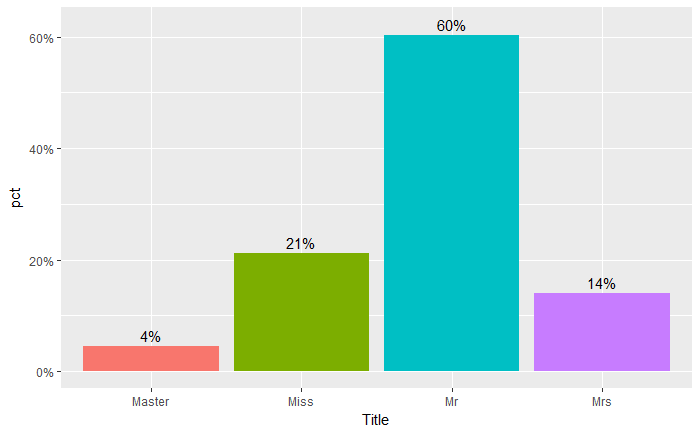

```r
# Title
data[1:891,] %>% group_by(Title) %>%
  summarise(count=n()) %>%
  mutate(pct=count/sum(count))  %>%
ggplot(aes(x=Title, y=pct, fill=Title)) +
  geom_bar(stat="identity") +
  scale_y_continuous(labels=percent) +
  geom_text(aes(label=paste0(round(pct*100,0),"%"), y=pct+0.02), size=4, colour= "black")+
  theme(legend.position = "none")
```

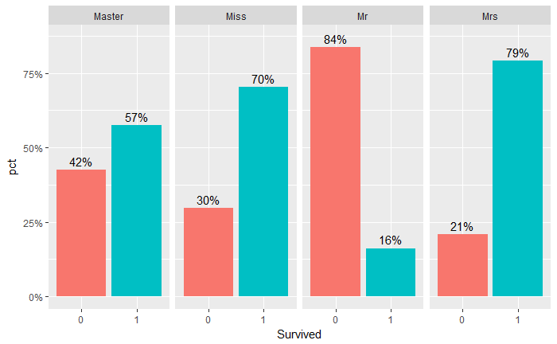

```r
# Title vs Survival
data[1:891,] %>% group_by(Title, Survived) %>%
  summarise(count=n()) %>%
  mutate(pct=count/sum(count))  %>%
ggplot(aes(x=Survived, y=pct, fill=Survived)) +
  geom_bar(stat="identity") +
  facet_grid(. ~ Title) +
  scale_y_continuous(labels=percent) +
  geom_text(aes(label=paste0(round(pct*100,0),"%"), y=pct+0.03), size=4, colour= "black")+
  theme(legend.position = "none")
```

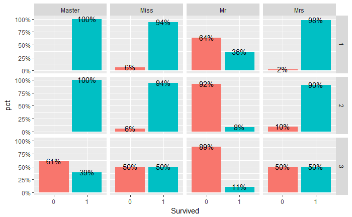

```r
# Title Vs vs survial under class
data[1:891,] %>% group_by(Pclass, Title, Survived) %>%
  summarise(count=n()) %>%
  mutate(pct=count/sum(count))  %>%
ggplot(aes(x=Survived, y=pct, fill=Survived)) +
  geom_bar(stat="identity") +
  facet_grid(Pclass ~ Title) +
  scale_y_continuous(labels=percent) +
  geom_text(aes(label=paste0(round(pct*100,0),"%"), y=pct+0.01), size=4, colour= "black")+
  theme(legend.position = "none")
```

Sex: It is clearly obvious that female have much more chance, 74%, to survive than male, 19%.

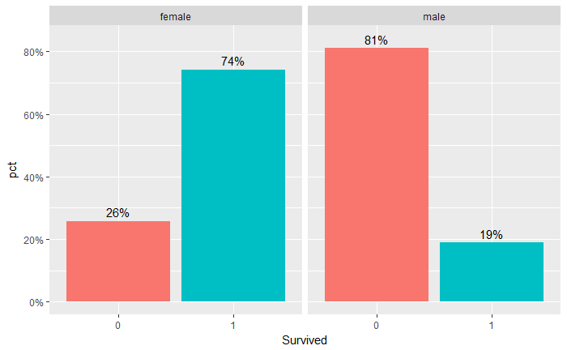

```r
#Sex
data[1:891,] %>% group_by(Sex, Survived) %>%
  summarise(count=n()) %>%
  mutate(pct=count/sum(count))  %>%
ggplot(aes(x=Survived, y=pct, fill=Survived)) +
  geom_bar(stat="identity") +
  facet_grid(. ~ Sex) +
  scale_y_continuous(labels=percent) +
  geom_text(aes(label=paste0(round(pct*100,0),"%"), y=pct+0.03), size=4, colour= "black")+
  theme(legend.position = "none")
```

Age Based on the plot of Title above, Mr in first class and Master, Miss, and Mrs in third class are difficult to predict if they would survive, so I focus on these passengers. From the plot, Age is associated with survival rate. Then it is preferable to keep the age feature and to impute the missing values.

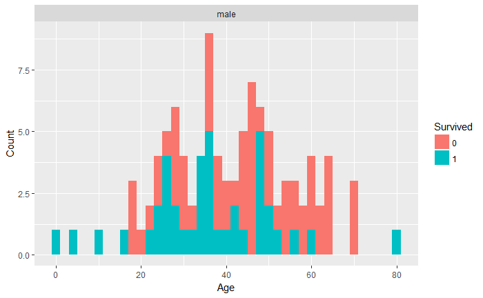

```r
#Age vs Survival under Sex
ggplot( subset(data[1:891,],!is.na(Age) & Pclass=="1" & Sex=="male") , aes(x = Age, fill=Survived)) +
  geom_histogram( binwidth=2)  +
  facet_wrap(~ Sex) +
  labs( x = "Age", y = "Count")
```

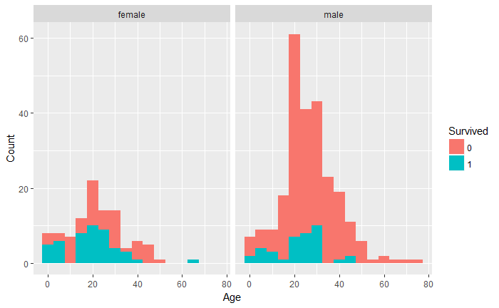

```r
ggplot( subset(data[1:891,],!is.na(Age) & Pclass=="3") , aes(x = Age, fill=Survived)) +
  geom_histogram( binwidth=5)  +
  facet_wrap(~ Sex) +
  labs( x = "Age", y = "Count")
```

how to impute missing values? method: Age1, impute Age by Title

```r
#method1: Age1, impute Age by Title
#create Age1
data$Age1=data$Age
#Title=Master
summary(data$Age[data$Title=="Master"])# 0.33-14.5, boys with median= 4.0
```

```
   Min. 1st Qu.  Median    Mean 3rd Qu.    Max.    NA's
  0.330   2.000   4.000   5.483   9.000  14.500       8
```

```r
masterAge <- data$Title == "Master" & is.na(data$Age)
data[masterAge, "Age1"] <- 4.0
# Title=Miss
summary(data$Age[data$Title=="Miss"]) # 0.17-63.0, median= 22.00, mean=22.16
```

```
   Min. 1st Qu.  Median    Mean 3rd Qu.    Max.    NA's
   0.17   16.00   22.00   22.16   30.00   63.00      51
```

```r
missAlone <- data$Title == "Miss" & data$Parch==0 & data$SibSp==0
summary(data[missAlone, "Age"]) # mean=27
```

```
   Min. 1st Qu.  Median    Mean 3rd Qu.    Max.    NA's
   5.00   21.00   26.00   27.38   33.00   58.00      34
```

```r
missAloneAge <- missAlone & is.na(data$Age)
data[missAloneAge, "Age1"] <- 27
missNot <- data$Title == "Miss" & (data$Parch + data$SibSp >0 )
summary(data[missNot, "Age"]) # mean=15
```

```
   Min. 1st Qu.  Median    Mean 3rd Qu.    Max.    NA's
   0.17    4.25   15.00   15.27   22.00   63.00      17
```

```r
missNotAge <- missNot & is.na(data$Age)
data[missNotAge, "Age1"] <- 15
#Title=Mrs
summary(data$Age[data$Title =="Mrs"]) # mean=37
```

```
   Min. 1st Qu.  Median    Mean 3rd Qu.    Max.    NA's
  14.00   27.00   35.50   36.99   46.50   76.00      27
```

```r
mrsAge <- data$Title == "Mrs" & is.na(data$Age)
data[mrsAge, "Age1"] <- 37
#Title=Mr
summary(data$Age[data$Title =="Mr"]) # mean=33
```

```
   Min. 1st Qu.  Median    Mean 3rd Qu.    Max.    NA's
   11.0    23.0    30.0    32.8    40.0    80.0     177
```

```r
mrAge <- data$Title == "Mr" & is.na(data$Age)
data[mrAge, "Age1"] <- 33
summary(data$Age1)
```

```
   Min. 1st Qu.  Median    Mean 3rd Qu.    Max.
   0.17   22.00   30.00   30.02   36.00   80.00
```

AgeGroup Based on the above Age plot, different Age group passengers had different chance to survive, so I group Age1. From the plot, the group of less than 7 years had the highest chance to survive, but the group of 28-35 had the least chance.Under pclass and Title, AgeGroup seems predictive.

```r
# group Age1 to AgeGroup
AgeGroup= cut(data$Age1, breaks = c(0,7,14.5 ,21,28,35,50,80), labels = c("0-7", "7-14.5","14.5-21","21-28","28-35","35-50","50-"))
table(AgeGroup)
```

```
AgeGroup
    0-7  7-14.5 14.5-21   21-28   28-35   35-50     50-
     74      43     198     280     365     254      95
```

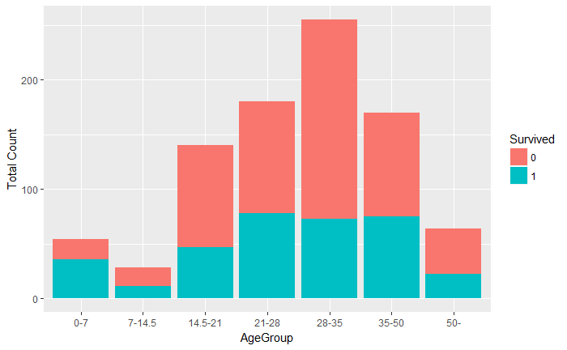

```r
data$AgeGroup=AgeGroup
#AgeGroup Vs Survival
ggplot(data[1:891,], aes(x = AgeGroup, fill=Survived)) +
  geom_bar() +
  xlab("AgeGroup") +
  ylab("Total Count") +
  labs(fill = "Survived")
```

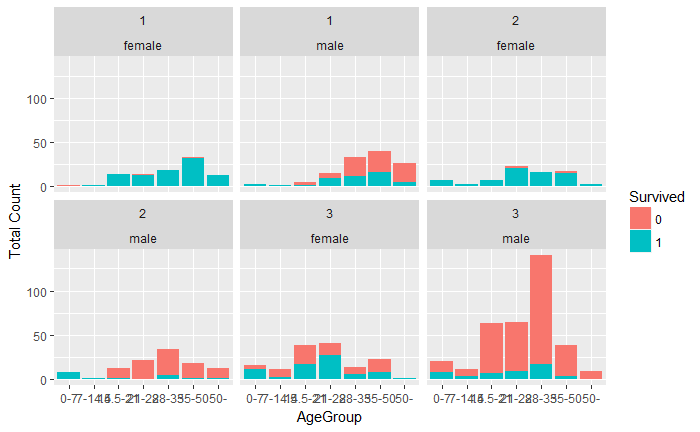

```r
# AgeGroup Vs Title, under Pclass, Survival
ggplot(data[1:891,], aes(x = AgeGroup, fill=Survived)) +
  geom_bar() +
  facet_wrap(Pclass~Sex)+
  xlab("AgeGroup") +
  ylab("Total Count") +
  labs(fill = "Survived")
```

Sibsp: It seems that passengers having more than 2 siblings/spouses had very little chance to survive. Then I group it to SibGroup.

```r
#Sibsp
summary(data$SibSp)
```

```
   Min. 1st Qu.  Median    Mean 3rd Qu.    Max.
 0.0000  0.0000  0.0000  0.4989  1.0000  8.0000
```

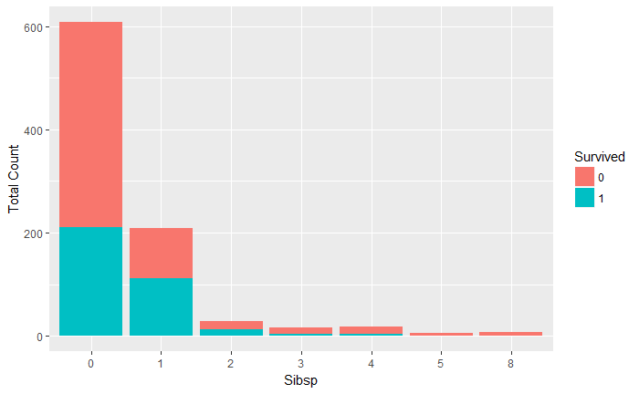

```r
ggplot(data[1:891,], aes(x = as.factor(SibSp), fill = Survived)) +
  geom_bar() +
  xlab("Sibsp") +
  ylab("Total Count") +
  labs(fill = "Survived")
```

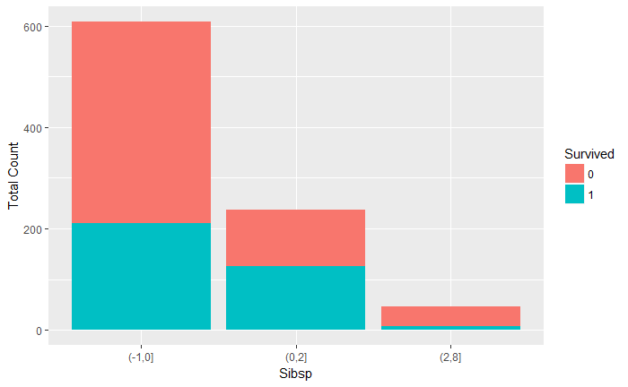

```r
# SibGroup
data$SibGroup <- cut(data$SibSp, breaks=c(-1,0,2,8),levels=c("0","1-2","3-"))
# SibGroup vs Survival under pclass and title
ggplot(data[1:891,], aes(x = SibGroup, fill = Survived)) +
  geom_bar() +
    xlab("Sibsp") +
  ylab("Total Count") +
  labs(fill = "Survived")
```

```r
#Parch
summary(data$Parch)
```

```
   Min. 1st Qu.  Median    Mean 3rd Qu.    Max.
  0.000   0.000   0.000   0.385   0.000   9.000
```

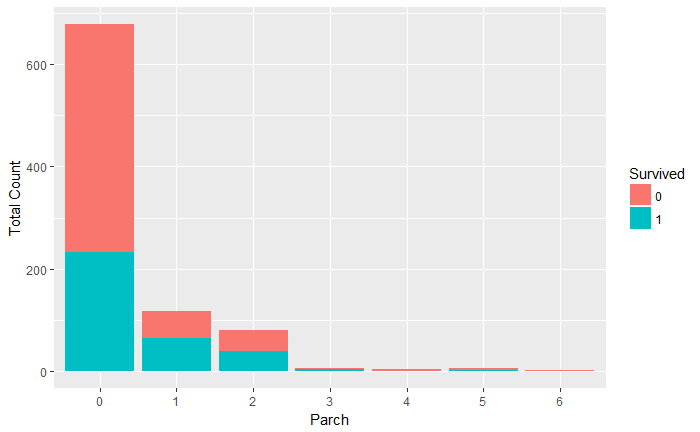

```r
ggplot(data[1:891,], aes(x = as.factor(Parch), fill = Survived)) +
  geom_bar() +
  xlab("Parch") +
  ylab("Total Count") +
  labs(fill = "Survived")
```

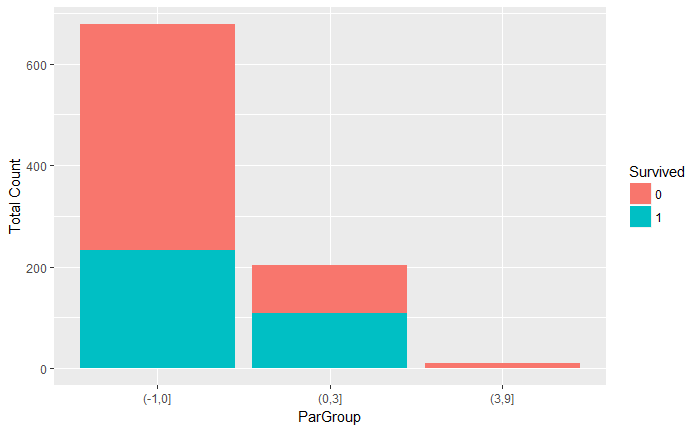

```r
# ParGroup
data$ParGroup <- cut(data$Parch, breaks=c(-1,0,3,9), levels=c("0","1-3","4-"))
# ParGroup vs Survival under pclass and title
ggplot(data[1:891,], aes(x = ParGroup, fill = Survived)) +
  geom_bar() +
  xlab("ParGroup") +
  ylab("Total Count") +
  labs(fill = "Survived")
```

FamilySize FamilySize=SibSp+Parch+1. From the plots, about 60% of passengers were traveling alone, and passengers traveling alone and having a big family size had less chance to survive.

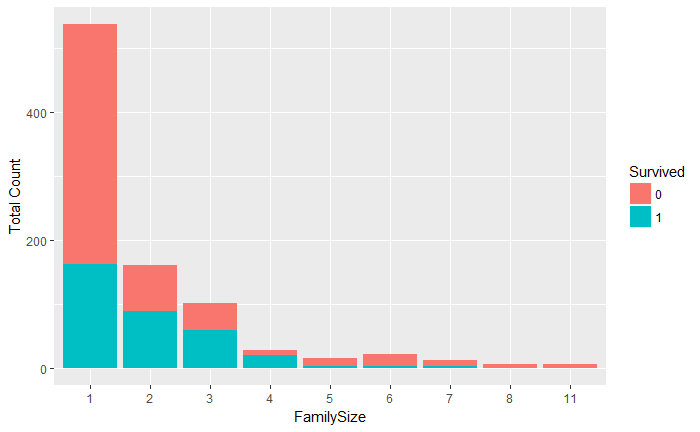

```r
# Create FamilySize
data$FamilySize <- with(data,SibSp+Parch+1 )
# FamilySize and survived are associated? Yes
ggplot(data[1:891,], aes(x = as.factor(FamilySize), fill = Survived)) +
  geom_bar() +
  xlab("FamilySize") +
  ylab("Total Count") +
  labs(fill = "Survived")
```

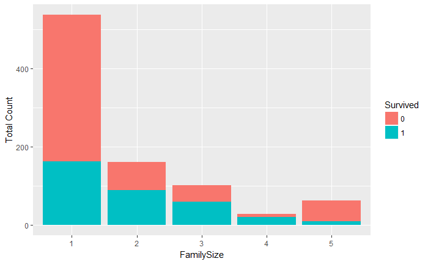

```r
# recode FamilySize since there are few examples for FamilySize>4
data$FamilySize[data$FamilySize>4] <- 5
# FamilySize vs survival
ggplot(data[1:891,], aes(x = as.factor(FamilySize), fill = Survived)) +
  geom_bar() +
  xlab("FamilySize") +
  ylab("Total Count") +
  labs(fill = "Survived")
```

Role * Parents, who needed to take care of their children have more chance to survive? Especially, when there were more than 1 kid, fathers were needed to help have more chance to survive? Refine Title varibale to look at. The result is surprising, parents have more chance to die.However, the differences between father and Mr, mother and Mrs are not much, so I will keep Title in modeling.

```r
# derive Role variable
Role <- as.character(data$Title)
#Father role
#Familysize>=4,
# father, 2 more kids
Father2 <- data$Title=="Mr" & data$SibSp==1 & data$FamilySize>3
Role[Father2 & (data$Age>20 | is.na(data$Age))]="father2"
# FamilySize==3,
# Father, one kid
Father1 <- data$Title=="Mr" & data$SibSp==1 & data$FamilySize==3
Role[Father1 & (data$Age>20 | is.na(data$Age))]="father1" # exclude cases of mother with two kids
#father, 2kids
Father2 <- data$Title=="Mr" & data$SibSp==0 & data$FamilySize==3
Role[Father2 & (data$Age>20 | is.na(data$Age))]="father2"
# FamilySize==2
#father, 1 kid
Father1 <- data$Title=="Mr" & data$SibSp==0 & data$FamilySize==2
Role[Father1 & (data$Age>25 | is.na(data$Age))]="father1" # exclude adult son
# Mother role
Mother <- data$Title=="Mrs" & data$Parch>0
Role[Mother]="mother"
# Role
table(Role)
```

```
Role
father1 father2  Master    Miss  mother      Mr     Mrs
     33      19      61     269      87     730     110
```

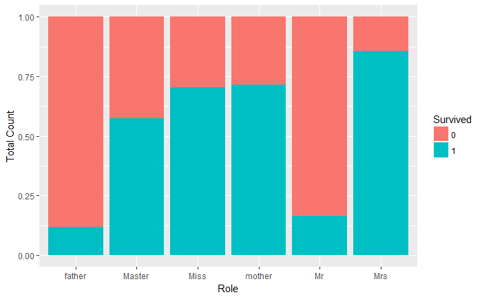

```r
data$Role <- Role
# combine father1 and father2 into father since there are only a few examples.
data$Role[data$Role=="father1" | data$Role=="father2" ]<- "father"
# convert to factor
data$Role<- as.factor(data$Role)
# Role Vs Survival
ggplot(data[1:891,], aes(x = Role, fill = Survived)) +
  geom_bar(position = 'fill') +
  xlab("Role") +
  ylab("Total Count") +
  labs(fill = "Survived")
```

```r
# convert type
data$FamilySize <- as.factor(data$FamilySize)
```

Ticket PartySize, the number of a group of people bought a joint ticket, so the fare for each person should be recalculated. PartySize, is like FamilySize, equals 1 or above 4 have high chance to die. Since the observations are limited when PartySize>4, I will combine them into 5 after I calculate the Fare for each passenger.

```r
# derive PartySize, the number of passengers sharing a ticket
arrange(filter(data,FamilySize=="5"),Ticket) # a group  share a ticket
```

| PassengerId | Survived | Pclass | Name | Sex | Age | SibSp | Parch | Ticket | Fare | Cabin | Embarked | Title | Age1 | AgeGroup | SibGroup | ParGroup | FamilySize | Role |
| --- | --- | --- | --- | --- | --- | --- | --- | --- | --- | --- | --- | --- | --- | --- | --- | --- | --- | --- |
| 28 | 0 | 1 | Fortune, Mr. Charles Alexander | male | 19.0 | 3 | 2 | 19950 | 263.0000 | C23 C25 C27 | S | Mr | 19.0 | 14.5-21 | (2,8] | (0,3] | 5 | Mr |
| 89 | 1 | 1 | Fortune, Miss. Mabel Helen | female | 23.0 | 3 | 2 | 19950 | 263.0000 | C23 C25 C27 | S | Miss | 23.0 | 21-28 | (2,8] | (0,3] | 5 | Miss |
| 342 | 1 | 1 | Fortune, Miss. Alice Elizabeth | female | 24.0 | 3 | 2 | 19950 | 263.0000 | C23 C25 C27 | S | Miss | 24.0 | 21-28 | (2,8] | (0,3] | 5 | Miss |
| 439 | 0 | 1 | Fortune, Mr. Mark | male | 64.0 | 1 | 4 | 19950 | 263.0000 | C23 C25 C27 | S | Mr | 64.0 | 50- | (0,2] | (3,9] | 5 | father |
| 945 | NA | 1 | Fortune, Miss. Ethel Flora | female | 28.0 | 3 | 2 | 19950 | 263.0000 | C23 C25 C27 | S | Miss | 28.0 | 21-28 | (2,8] | (0,3] | 5 | Miss |
| 961 | NA | 1 | Fortune, Mrs. Mark (Mary McDougald) | female | 60.0 | 1 | 4 | 19950 | 263.0000 | C23 C25 C27 | S | Mrs | 60.0 | 50- | (0,2] | (3,9] | 5 | mother |
| 775 | 1 | 2 | Hocking, Mrs. Elizabeth (Eliza Needs) | female | 54.0 | 1 | 3 | 29105 | 23.0000 |  | S | Mrs | 54.0 | 50- | (0,2] | (0,3] | 5 | mother |
| 438 | 1 | 2 | Richards, Mrs. Sidney (Emily Hocking) | female | 24.0 | 2 | 3 | 29106 | 18.7500 |  | S | Mrs | 24.0 | 21-28 | (0,2] | (0,3] | 5 | mother |
| 69 | 1 | 3 | Andersson, Miss. Erna Alexandra | female | 17.0 | 4 | 2 | 3101281 | 7.9250 |  | S | Miss | 17.0 | 14.5-21 | (2,8] | (0,3] | 5 | Miss |
| 51 | 0 | 3 | Panula, Master. Juha Niilo | male | 7.0 | 4 | 1 | 3101295 | 39.6875 |  | S | Master | 7.0 | 0-7 | (2,8] | (0,3] | 5 | Master |

[output cut: 72 more lines]

```r
ticket.party <- data %>%
             group_by(Ticket) %>%
             summarise(PartySize=n())
# merge PartySize to data
data <- left_join(data,ticket.party,by="Ticket")
# look at PartySize
table(data$PartySize)
```

```
  1   2   3   4   5   6   7   8  11
713 264 147  64  35  24  35  16  11
```

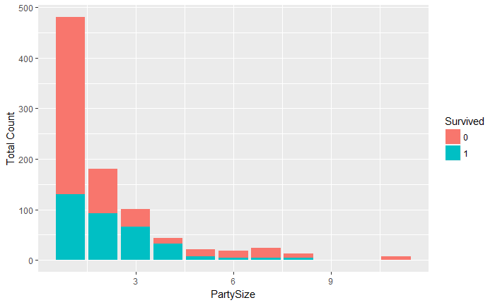

```r
# Partysize vs survival
ggplot(data[1:891,], aes(x = PartySize, fill = Survived)) +
  geom_bar() +
  xlab("PartySize") +
  ylab("Total Count") +
  labs(fill = "Survived")
```

Fare FareEach,Fare for each passenger. FareGroup, group FareEach, the more a passenger paid, the more chance of survival they had.

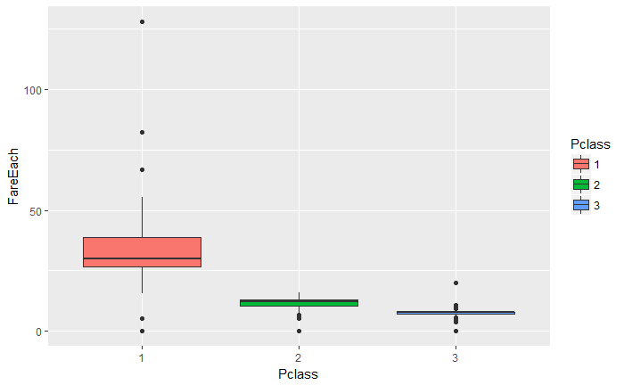

```r
# recalculate fare for each passenger
data$FareEach <- with(data, Fare/PartySize)
# impute missing values
#Intuitively, FareEach should be associated with Pclass, the boxplot proves this.
# disributions of FareEach for Pclass
ggplot(data[1:891,], aes(x = Pclass, y = FareEach, fill = Pclass)) +
  geom_boxplot() +
  xlab("Pclass") +
  ylab("FareEach")
```

```r
summary(data$Fare)
```

```
   Min. 1st Qu.  Median    Mean 3rd Qu.    Max.    NA's
  0.000   7.896  14.450  33.300  31.280 512.300       1
```

```r
filter(data, is.na(Fare))
```

| PassengerId | Survived | Pclass | Name | Sex | Age | SibSp | Parch | Ticket | Fare | Cabin | Embarked | Title | Age1 | AgeGroup | SibGroup | ParGroup | FamilySize | Role | PartySize | FareEach |
| --- | --- | --- | --- | --- | --- | --- | --- | --- | --- | --- | --- | --- | --- | --- | --- | --- | --- | --- | --- | --- |
| 1044 | NA | 3 | Storey, Mr. Thomas | male | 60.5 | 0 | 0 | 3701 | NA |  | S | Mr | 60.5 | 50- | (-1,0] | (-1,0] | 1 | Mr | 1 | NA |

```r
summary(data[which(data$Pclass==3),"FareEach"]) # mean=7.329
```

```
   Min. 1st Qu.  Median    Mean 3rd Qu.    Max.    NA's
  0.000   7.060   7.750   7.329   7.925  19.970       1
```

```r
data$FareEach[which(is.na(data$Fare))] <- 7.329
# Fare is associated with Suvival?
summary(data$FareEach)
```

```
   Min. 1st Qu.  Median    Mean 3rd Qu.    Max.
   0.00    7.55    8.05   14.75   15.00  128.10
```

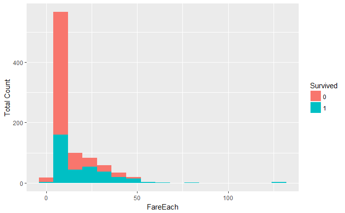

```r
ggplot(data[1:891,], aes(x = FareEach, fill = Survived)) +
  geom_histogram(binwidth = 8) +
  xlab("FareEach") +
  ylab("Total Count") +
  labs(fill = "Survived")
```

```r
# group FareEach by quantile
summary(data$FareEach)
```

```
   Min. 1st Qu.  Median    Mean 3rd Qu.    Max.
   0.00    7.55    8.05   14.75   15.00  128.10
```

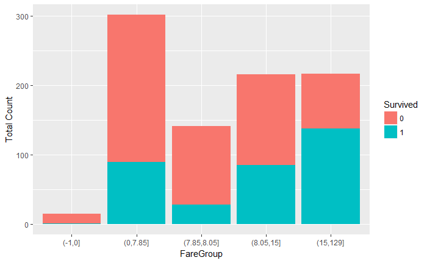

```r
data$FareGroup <- cut(data$FareEach, breaks=c(-1,0,7.85,8.05,15.00,129))
# FareGroup vs Survival
ggplot(data[1:891,], aes(x = FareGroup, fill = Survived)) +
geom_bar()+
xlab("FareGroup") +
ylab("Total Count") +
labs(fill = "Survived")
```

```r
# recode PartySize since there are few examples for PartySize>4
data$PartySize[data$PartySize>5] <- 5
data$PartySize <- as.factor(data$PartySize)
```

Cabin CabinFirst, the first letter of Cabin, may represent different position of the ship, so it may associated with survival rate. The plot proves it. Passengers whose Cabins’ first letters are B,C,D,E,F had more chance to survive. However, most passengers didn’t have a cabin, and these had much less chance to survive than those having a cabin. I will create a feature, HaveCabin, indicate if a passenger had a cabin, and use it in modeling.

```r
# Replace empty cabins with a "U"
length(unique(data$Cabin))
```

```
[1] 187
```

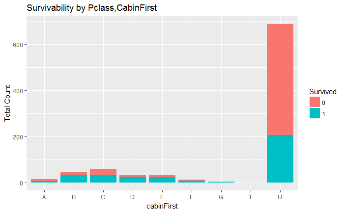

```r
data$Cabin[data$Cabin == ""] <- "U"
# Take a look at just the first letter as a factor
data$CabinFirst <- as.factor(substr(data$Cabin, 1, 1))
# Plot
# Cabin is associated with survival rate? Yes
ggplot(data[1:891,], aes(x = CabinFirst, fill = Survived)) +
  geom_bar() +
  ggtitle("Survivability by Pclass,CabinFirst") +
  xlab("cabinFirst") +
  ylab("Total Count") +
  labs(fill = "Survived")
```

```r
data$HaveCabin <- as.factor(ifelse(data$Cabin=="U","0","1"))
```

Side: Since the ship was hitted on the left side, maybe side is a good predictor. Maybe Cabin’s last number, like house/room number, can have the information. The plot shows passengers having cabins on the left side of the ship had slightly less chance to survive than those on the right side.

```r
CabinLast <- str_sub(data$Cabin, -1, -1)
table(CabinLast)
```

```
CabinLast
   0    1    2    3    4    5    6    7    8    9    D    F    T    U
  30   29   24   25   28   27   45   28   32   21    4    1    1 1014
```

```r
Side <- rep("unknown",length(CabinLast))
Side[CabinLast %in% c("0","2","4","6", "8")] <- "left"
Side[CabinLast %in% c("1","3","5","7", "9")] <- "right"
# convert into factor
table(Side)
```

```
Side
   left   right unknown
    159     130    1020
```

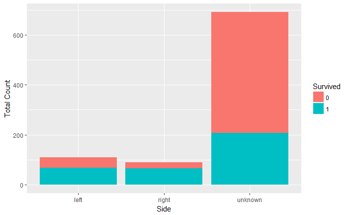

```r
data$Side <- factor(Side)
# Side Vs Survival
ggplot(data[1:891,], aes(x = Side, fill = Survived)) +
  geom_bar() +
  xlab("Side") +
  ylab("Total Count") +
  labs(fill = "Survived")
```

Embarked: It seems that passenger coming from Cherbourg (C) had more chance to survive. Maybe the proportion of first class passengers was higher for those from Cherbourg than those from Queenstown (Q), Southampton (S).The plot proves it. The passengers from Queenstown (Q) are almost third class, but the survival rate is much higher than that of the third class. From the table, there are more children and women, 53%, in those from Queenstown (Q).

```r
# understand Embarked
table(data$Embarked)
```

```
      C   Q   S
  2 270 123 914
```

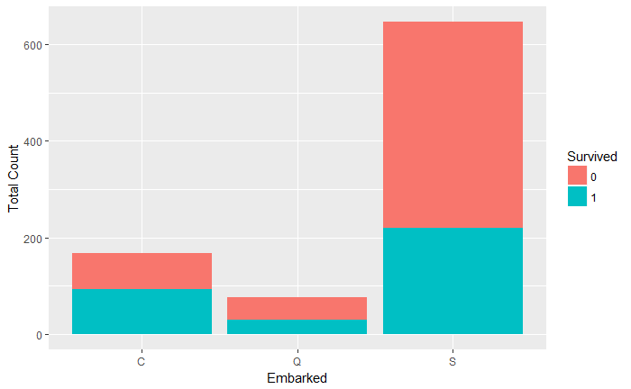

```r
# replace missing values with mode
data[which(data$Embarked==""),"Embarked"]<-"S"
# drop missing values level
data$Embarked<-factor(data$Embarked, levels=c("C","Q","S"))
# the survival rate is associated with where the passengers are from?
ggplot(data[1:891,], aes(x = Embarked, fill = Survived)) +
  geom_bar() +
  xlab("Embarked") +
  ylab("Total Count") +
  labs(fill = "Survived")
```

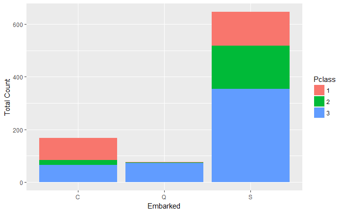

```r
# the proportion of first class passengers is higher for those from Cherbourg? Yes
ggplot(data[1:891,], aes(x = Embarked, fill = Pclass)) +
  geom_bar() +
  xlab("Embarked") +
  ylab("Total Count") +
  labs(fill = "Pclass")
```

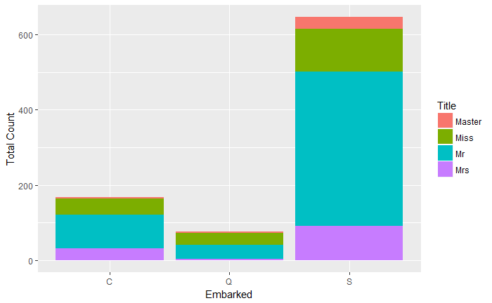

```r
# there are more children and women in those from Queenstown (Q)? Yes
ggplot(data[1:891,], aes(x = Embarked, fill = Title)) +
  geom_bar() +
  xlab("Embarked") +
  ylab("Total Count") +
  labs(fill = "Title")
```

```r
prop.table(table(data$Embarked, data$Title),1)
```

```
        Master       Miss         Mr        Mrs
  C 0.04074074 0.20000000 0.54074074 0.21851852
  Q 0.04065041 0.45528455 0.47154472 0.03252033
  S 0.04912664 0.17358079 0.63100437 0.14628821
```

# Data preparation - creating training and test datasets

Create training dataset to build models and test dataset to make predictions.

```r
# split the data frames to training and test datasets
train.df <- data[1:891, c( "Survived", "Pclass", "Sex", "Embarked", "Title", "AgeGroup", "SibGroup", "ParGroup", "FamilySize", "PartySize", "FareGroup", "HaveCabin")]
train.df$Survived <- factor(train.df$Survived, levels = c("0","1"))
test.df <- data[892:1309, c( "Pclass", "Sex", "Embarked", "Title", "AgeGroup", "SibGroup", "ParGroup", "FamilySize", "PartySize", "FareGroup", "HaveCabin")]
```

# check type of features

```r
str(train.df)
```

```
'data.frame':   891 obs. of  12 variables:
 $ Survived  : Factor w/ 2 levels "0","1": 1 2 2 2 1 1 1 1 2 2 ...
 $ Pclass    : Factor w/ 3 levels "1","2","3": 3 1 3 1 3 3 1 3 3 2 ...
 $ Sex       : Factor w/ 2 levels "female","male": 2 1 1 1 2 2 2 2 1 1 ...
 $ Embarked  : Factor w/ 3 levels "C","Q","S": 3 1 3 3 3 2 3 3 3 1 ...
 $ Title     : Factor w/ 4 levels "Master","Miss",..: 3 4 2 4 3 3 3 1 4 4 ...
 $ AgeGroup  : Factor w/ 7 levels "0-7","7-14.5",..: 4 6 4 5 5 5 7 1 4 2 ...
 $ SibGroup  : Factor w/ 3 levels "(-1,0]","(0,2]",..: 2 2 1 2 1 1 1 3 1 2 ...
 $ ParGroup  : Factor w/ 3 levels "(-1,0]","(0,3]",..: 1 1 1 1 1 1 1 2 2 1 ...
 $ FamilySize: Factor w/ 5 levels "1","2","3","4",..: 2 2 1 2 1 1 1 5 3 2 ...
 $ PartySize : Factor w/ 5 levels "1","2","3","4",..: 1 2 1 2 1 1 2 5 3 2 ...
 $ FareGroup : Factor w/ 5 levels "(-1,0]","(0,7.85]",..: 2 5 3 5 3 4 5 2 2 5 ...
 $ HaveCabin : Factor w/ 2 levels "0","1": 1 2 1 2 1 1 2 1 1 1 ...
```

## Step 3: Training and evaluating models on the training dataset —-

# store fitted accuracy and cross validation accuracy.

```r
train.acc <- numeric(5)
cv.acc <- numeric(5)
```

# build a gbm model

```r
# tune parameters
ctrl <- trainControl(method = "cv",
                     number = 10 )
grid_gbm <-  expand.grid(interaction.depth = c(5, 7, 9),
                        n.trees = (1:4)*50,
                        shrinkage = 0.01,
                        n.minobsinnode = c(12, 14, 16, 18))

set.seed(1234)
m_gbm1 <- train(Survived ~ ., data = train.df,
                 method = "gbm",
                 trControl = ctrl,
                 verbose = FALSE,
                 tuneGrid = grid_gbm,
                 metric = "Accuracy")
m_gbm1$bestTune
```

|  | n.trees | interaction.depth | shrinkage | n.minobsinnode |
| --- | --- | --- | --- | --- |
| 22 | 100 | 7 | 0.01 | 14 |

```r
# Evaluate model performance by cross validation
set.seed(1234)
m_gbm <- train(Survived ~ ., data = train.df,
                 method = "gbm",
                 trControl = ctrl,
                 verbose = FALSE,
                 tuneGrid = m_gbm1$bestTune,
                 metric = "Accuracy")
#accuracy
train.acc[1] <- mean(predict(m_gbm,train.df)== train.df$Survived)
train.acc[1]
```

```
[1] 0.8439955
```

```r
cv.acc[1] <- m_gbm$results$Accuracy
cv.acc[1]
```

```
[1] 0.839508
```

```r
# look at feature importance
imp.gbm <- varImp(m_gbm, scale = FALSE)
imp.gbm
```

```
gbm variable importance

  only 20 most important variables shown (out of 31)

                   Overall
TitleMr           1272.918
Pclass3            370.200
Sexmale            191.694
PartySize5         143.111
FamilySize5         86.155
FareGroup(15,129]   81.265
HaveCabin1          76.702
EmbarkedS           41.661
FareGroup(0,7.85]   37.984
SibGroup(2,8]       24.552
AgeGroup21-28       11.836
PartySize2          11.090
SibGroup(0,2]       10.631
AgeGroup35-50       10.037
ParGroup(0,3]        9.452
AgeGroup50-          9.179
TitleMiss            8.718
EmbarkedQ            7.754
TitleMrs             6.433
FamilySize2          6.410
```

# build a random forest model

```r
# tune parameters
grid_rf <- expand.grid( .mtry = c(2, 3, 4, 5))
set.seed(1234)
m_rf1 <- train(Survived ~ .,  data=train.df,
              method = "rf",
              metric = "Accuracy",
              trControl = ctrl,
              tuneGrid = grid_rf)
m_rf1$bestTune
```

|  | mtry |
| --- | --- |
| 2 | 3 |

```r
# Evaluate model performance by cross validation
set.seed(1234)
m_rf <- train(Survived ~ ., data = train.df,
                 method = "rf",
                 metric = "Accuracy",
                 trControl = ctrl,
                 tuneGrid = m_rf1$bestTune
                 )
#accuracy
train.acc[2] <- mean(predict(m_rf,train.df)== train.df$Survived)
train.acc[2]
```

```
[1] 0.8664422
```

```r
cv.acc[2] <- m_rf$results$Accuracy
cv.acc[2]
```

```
[1] 0.8294337
```

```r
# look at feature importance
imp.rf <- varImp(m_rf, scale = FALSE)
imp.rf
```

```
rf variable importance

  only 20 most important variables shown (out of 31)

                   Overall
TitleMr             46.703
Sexmale             35.384
TitleMiss           17.111
TitleMrs            16.272
Pclass3             13.988
HaveCabin1          11.808
FareGroup(15,129]   10.567
PartySize5           6.659
PartySize3           5.121
FareGroup(0,7.85]    5.054
FamilySize5          4.941
EmbarkedS            4.845
ParGroup(0,3]        4.765
Pclass2              4.714
SibGroup(0,2]        4.444
AgeGroup21-28        3.756
FareGroup(8.05,15]   3.656
FamilySize3          3.544
PartySize2           3.525
FamilySize2          3.457
```

# build a xgboost model

```r
# tune parameters
grid_xg <- expand.grid( nrounds= (1:4)*50,
                        max_depth= c(7, 9, 11),
                        eta= 0.3,
                        gamma=0,
                        min_child_weight=c(6,8,10),
                        colsample_bytree= c(0.6, 0.8, 1),
                        subsample=1)
set.seed(1234)
m_xg1 <- train(Survived ~ .,  data=train.df,
               method = "xgbTree",
               metric = "Accuracy",
               trControl = ctrl,
               tuneGrid = grid_xg)
m_xg1$bestTune
```

|  | nrounds | max_depth | eta | gamma | colsample_bytree | min_child_weight | subsample |
| --- | --- | --- | --- | --- | --- | --- | --- |
| 62 | 100 | 9 | 0.3 | 0 | 1 | 6 | 1 |

```r
# Evaluate model performance by cross validation
set.seed(1234)
m_xg <- train(Survived ~ ., data = train.df,
                 method = "xgbTree",
                 metric = "Accuracy",
                 trControl = ctrl,
                 tuneGrid = m_xg1$bestTune
                 )
#accuracy
train.acc[3] <- mean(predict(m_xg,train.df)== train.df$Survived)
train.acc[3]
```

```
[1] 0.8799102
```

```r
cv.acc[3] <- m_xg$results$Accuracy
cv.acc[3]
```

```
[1] 0.8338268
```

```r
# look at feature importance
imp.xg <- varImp(m_xg, scale = FALSE)
imp.xg
```

```
xgbTree variable importance

  only 20 most important variables shown (out of 31)

                      Overall
TitleMr              0.471658
Pclass3              0.153248
PartySize5           0.075372
FareGroup(15,129]    0.039956
HaveCabin1           0.037084
FareGroup(0,7.85]    0.030441
EmbarkedS            0.022529
FareGroup(7.85,8.05] 0.019584
AgeGroup21-28        0.017209
AgeGroup35-50        0.014784
FareGroup(8.05,15]   0.012722
SibGroup(0,2]        0.011996
AgeGroup28-35        0.011380
TitleMiss            0.011131
PartySize2           0.011126
ParGroup(0,3]        0.009285
AgeGroup14.5-21      0.008611
Sexmale              0.007275
PartySize3           0.006151
EmbarkedQ            0.006010
```

# build a logistic regression model

```r
# select features
# fit a logistic regression model with all features
model.glm1=glm(Survived ~ ., data=train.df,
              family= "binomial" )
# significnat test
anova(model.glm1, test="Chisq")
```

```
Analysis of Deviance Table

Model: binomial, link: logit

Response: Survived

Terms added sequentially (first to last)

           Df Deviance Resid. Df Resid. Dev  Pr(>Chi)
NULL                         890    1186.66
Pclass      2  103.547       888    1083.11 < 2.2e-16 ***
Sex         1  256.220       887     826.89 < 2.2e-16 ***
Embarked    2    7.863       885     819.03   0.01962 *
Title       3   49.215       882     769.81 1.174e-10 ***
AgeGroup    6   13.217       876     756.59   0.03972 *
SibGroup    2   35.077       874     721.52 2.416e-08 ***
ParGroup    2    8.711       872     712.81   0.01284 *
FamilySize  4    4.704       868     708.10   0.31909
PartySize   4    4.220       864     703.88   0.37706
FareGroup   4    5.844       860     698.04   0.21108
HaveCabin   1    4.268       859     693.77   0.03883 *
---
Signif. codes:  0 ?**?0.001 ?*?0.01 ??0.05 ??0.1 ??1
```

```r
# drop insignificant features and  fit a  model
model.glm2=glm(Survived ~ Pclass + Sex + Embarked + Title + AgeGroup + SibGroup + ParGroup + HaveCabin,
               data=train.df,
               family = "binomial" )

# goodness of fit test
library(ResourceSelection)
hl <- hoslem.test(model.glm2$y, fitted(model.glm2), g=10)
hl # p-value=0.08, poor fit
```

```
    Hosmer and Lemeshow goodness of fit (GOF) test

data:  model.glm2$y, fitted(model.glm2)
X-squared = 14.139, df = 8, p-value = 0.07821
```

```r
# add interation effects and use sepwise to select features
step.glm <- step(model.glm2,
                 scope = list(upper = as.formula(Survived ~ .^2),
                              lower = as.formula(Survived ~ .)),
                 direction = "both")
```

```
Start:  AIC=748
Survived ~ Pclass + Sex + Embarked + Title + AgeGroup + SibGroup +
    ParGroup + HaveCabin
```

```
glm.fit: algorithm did not convergeglm.fit: fitted probabilities numerically 0 or 1 occurred
```

```
                     Df Deviance    AIC
+ Pclass:Sex          2   685.99 729.99
+ Pclass:Title        6   681.38 733.38
+ Sex:SibGroup        2   691.57 735.57
+ Title:SibGroup      6   687.92 739.92
+ Pclass:ParGroup     3   698.77 744.77
+ Embarked:ParGroup   3   699.35 745.35
+ SibGroup:ParGroup   3   699.50 745.50
+ Pclass:SibGroup     4   698.34 746.34
+ AgeGroup:SibGroup  10   686.85 746.85
+ SibGroup:HaveCabin  2   703.64 747.64
<none>                    708.00 748.00
+ Embarked:SibGroup   3   702.72 748.72
+ Sex:HaveCabin       1   707.71 749.71
+ Sex:Embarked        2   705.82 749.82
+ Sex:Title           1   708.00 750.00
+ Embarked:HaveCabin  2   706.75 750.75
+ Sex:ParGroup        2   707.48 751.48
+ Pclass:HaveCabin    2   707.62 751.62
+ ParGroup:HaveCabin  2   707.94 751.94
+ Title:HaveCabin     3   706.34 752.34
+ Embarked:Title      6   700.83 752.83
+ AgeGroup:HaveCabin  6   701.45 753.45
+ Title:ParGroup      4   706.13 754.13
+ Pclass:AgeGroup    12   690.13 754.13
+ Pclass:Embarked     4   707.14 755.14
+ Sex:AgeGroup        6   703.66 755.66
+ Embarked:AgeGroup  12   695.94 759.94
+ AgeGroup:ParGroup   8   706.56 762.56
+ Title:AgeGroup     12   701.42 765.42

Step:  AIC=729.99
Survived ~ Pclass + Sex + Embarked + Title + AgeGroup + SibGroup +
    ParGroup + HaveCabin + Pclass:Sex
```

```
glm.fit: algorithm did not convergeglm.fit: fitted probabilities numerically 0 or 1 occurred
```

```
                     Df Deviance    AIC
+ Sex:SibGroup        2   665.81 713.81
+ Title:SibGroup      6   661.49 717.49
+ SibGroup:ParGroup   3   676.62 726.62
+ Sex:Embarked        2   679.23 727.23
+ Embarked:ParGroup   3   677.46 727.46
+ AgeGroup:SibGroup  10   664.40 728.40
+ Sex:HaveCabin       1   683.80 729.80
<none>                    685.99 729.99
+ Embarked:SibGroup   3   680.53 730.53
+ Embarked:Title      6   674.68 730.68
+ SibGroup:HaveCabin  2   683.09 731.09
+ Sex:Title           1   685.99 731.99
+ Embarked:HaveCabin  2   684.25 732.25
+ Pclass:SibGroup     4   680.34 732.34
+ Pclass:ParGroup     3   682.92 732.92
+ Title:HaveCabin     3   682.95 732.95
+ Pclass:Title        4   681.38 733.38
+ Pclass:AgeGroup    12   665.45 733.45
+ Pclass:HaveCabin    2   685.78 733.78
+ Sex:ParGroup        2   685.82 733.82
+ ParGroup:HaveCabin  2   685.92 733.92
+ AgeGroup:HaveCabin  6   680.65 736.65
+ Pclass:Embarked     4   684.94 736.94
+ Title:ParGroup      4   685.06 737.06
+ Sex:AgeGroup        6   681.36 737.36
+ Embarked:AgeGroup  12   669.90 737.90
+ Title:AgeGroup     12   676.46 744.46
+ AgeGroup:ParGroup   8   684.59 744.59
- Pclass:Sex          2   708.00 748.00

Step:  AIC=713.81
Survived ~ Pclass + Sex + Embarked + Title + AgeGroup + SibGroup +
    ParGroup + HaveCabin + Pclass:Sex + Sex:SibGroup
```

[output not shown]

```
                     Df Deviance     AIC
+ Sex:Embarked        2    658.8   710.8
<none>                     665.8   713.8
+ Embarked:ParGroup   3    660.0   714.0
+ Sex:HaveCabin       1    664.0   714.0
+ SibGroup:ParGroup   3    660.6   714.6
+ Embarked:HaveCabin  2    663.7   715.7
+ Sex:Title           1    665.8   715.8
+ Embarked:SibGroup   3    662.3   716.3
+ SibGroup:HaveCabin  2    664.5   716.5
+ Pclass:AgeGroup    12    645.2   717.2
+ Embarked:Title      6    657.2   717.2
+ Pclass:HaveCabin    2    665.6   717.6
+ Pclass:ParGroup     3    663.7   717.7
+ Sex:ParGroup        2    665.7   717.7
+ ParGroup:HaveCabin  2    665.7   717.7
+ AgeGroup:HaveCabin  6    657.8   717.8
+ Title:HaveCabin     3    663.8   717.8
+ Pclass:SibGroup     4    663.4   719.4
+ Title:SibGroup      5    661.5   719.5
+ Pclass:Embarked     4    664.6   720.6
+ Pclass:Title        4    665.2   721.2
+ Title:ParGroup      4    665.6   721.6
+ AgeGroup:SibGroup  10    654.5   722.5
+ Embarked:AgeGroup  12    651.2   723.2
+ Sex:AgeGroup        6    663.6   723.6
- Sex:SibGroup        2    686.0   730.0
+ AgeGroup:ParGroup   9    666.0   732.0
- Pclass:Sex          2    691.6   735.6
+ Title:AgeGroup     11  11173.5 11243.5

Step:  AIC=710.82
Survived ~ Pclass + Sex + Embarked + Title + AgeGroup + SibGroup +
    ParGroup + HaveCabin + Pclass:Sex + Sex:SibGroup + Sex:Embarked
```

[output not shown]

```
                     Df Deviance     AIC
+ Embarked:ParGroup   3    651.6   709.6
<none>                     658.8   710.8
+ Sex:HaveCabin       1    657.2   711.2
+ SibGroup:ParGroup   3    653.5   711.5
+ Embarked:HaveCabin  2    656.4   712.4
+ Sex:Title           1    658.8   712.8
+ SibGroup:HaveCabin  2    657.6   713.6
- Sex:Embarked        2    665.8   713.8
+ Embarked:SibGroup   3    656.0   714.0
+ Pclass:AgeGroup    12    638.5   714.5
+ Pclass:ParGroup     3    656.6   714.6
+ Sex:ParGroup        2    658.7   714.7
+ ParGroup:HaveCabin  2    658.7   714.7
+ Pclass:HaveCabin    2    658.7   714.7
+ AgeGroup:HaveCabin  6    650.7   714.7
+ Title:HaveCabin     3    657.1   715.1
+ Pclass:SibGroup     4    656.4   716.4
+ Title:SibGroup      5    654.9   716.9
+ Embarked:Title      4    657.2   717.2
+ Pclass:Title        4    657.9   717.9
+ Pclass:Embarked     4    658.4   718.4
+ Title:ParGroup      4    658.7   718.7
+ AgeGroup:SibGroup  10    647.8   719.8
+ Sex:AgeGroup        6    656.7   720.7
+ AgeGroup:ParGroup   8    657.4   725.4
+ Embarked:AgeGroup  12    650.4   726.4
- Sex:SibGroup        2    679.2   727.2
- Pclass:Sex          2    689.5   737.5
+ Title:AgeGroup     11  13047.8 13121.8

Step:  AIC=709.56
Survived ~ Pclass + Sex + Embarked + Title + AgeGroup + SibGroup +
    ParGroup + HaveCabin + Pclass:Sex + Sex:SibGroup + Sex:Embarked +
    Embarked:ParGroup
```

[output not shown]

```
                     Df Deviance     AIC
<none>                     651.6   709.6
+ Sex:HaveCabin       1    650.0   710.0
- Embarked:ParGroup   3    658.8   710.8
+ Embarked:HaveCabin  2    649.4   711.4
+ SibGroup:ParGroup   3    647.5   711.5
+ Sex:Title           1    651.6   711.6
+ Embarked:SibGroup   3    647.7   711.7
+ SibGroup:HaveCabin  2    650.3   712.3
+ Sex:ParGroup        2    651.2   713.2
+ ParGroup:HaveCabin  2    651.3   713.3
+ Pclass:HaveCabin    2    651.5   713.5
+ Pclass:AgeGroup    12    631.6   713.6
+ AgeGroup:HaveCabin  6    643.7   713.7
+ Title:HaveCabin     3    649.8   713.8
+ Pclass:ParGroup     3    649.9   713.9
- Sex:Embarked        2    660.0   714.0
+ Pclass:SibGroup     4    649.0   715.0
+ Pclass:Title        4    650.3   716.3
+ Pclass:Embarked     4    651.1   717.1
+ Embarked:Title      4    651.1   717.1
+ Title:ParGroup      4    651.2   717.2
+ Sex:AgeGroup        6    648.9   718.9
+ AgeGroup:SibGroup  10    641.7   719.7
+ AgeGroup:ParGroup   8    649.1   723.1
- Sex:SibGroup        2    670.5   724.5
+ Embarked:AgeGroup  12    645.6   727.6
- Pclass:Sex          2    682.4   736.4
+ Title:SibGroup      4  12182.8 12248.8
+ Title:AgeGroup     12  22563.3 22645.3
```

```r
# train a model with the features stepwise selected
model.glm <- glm(Survived ~ Pclass + Sex + Embarked + Title + AgeGroup + SibGroup +
    ParGroup + HaveCabin + Pclass:Sex + Sex:SibGroup + Sex:Embarked + Embarked:ParGroup,
                 data=train.df,
                 family ="binomial")
summary(model.glm)
```

```
Call:
glm(formula = Survived ~ Pclass + Sex + Embarked + Title + AgeGroup +
    SibGroup + ParGroup + HaveCabin + Pclass:Sex + Sex:SibGroup +
    Sex:Embarked + Embarked:ParGroup, family = "binomial", data = train.df)

Deviance Residuals:
    Min       1Q   Median       3Q      Max
-2.8768  -0.5156  -0.4121   0.3137   2.5778

Coefficients: (1 not defined because of singularities)
                         Estimate Std. Error z value Pr(>|z|)
(Intercept)               39.2872  2730.4427   0.014  0.98852
Pclass2                   -0.4702     0.8212  -0.573  0.56692
Pclass3                   -3.1542     0.7219  -4.369 1.25e-05 ***
Sexmale                  -19.8254  2664.3652  -0.007  0.99406
EmbarkedQ                  1.0162     0.7317   1.389  0.16489
EmbarkedS                 -0.7530     0.5774  -1.304  0.19220
TitleMiss                -34.0362  2730.4426  -0.012  0.99005
TitleMr                  -18.4822   597.0554  -0.031  0.97530
TitleMrs                 -33.0352  2730.4426  -0.012  0.99035
AgeGroup7-14.5            -2.1368     0.8796  -2.429  0.01512 *
AgeGroup14.5-21           -1.6789     0.6998  -2.399  0.01644 *
AgeGroup21-28             -1.6126     0.7246  -2.225  0.02605 *
AgeGroup28-35             -1.6244     0.7435  -2.185  0.02891 *
AgeGroup35-50             -2.0853     0.7639  -2.730  0.00634 **
AgeGroup50-               -2.5923     0.8418  -3.080  0.00207 **
SibGroup(0,2]             -0.5442     0.3995  -1.362  0.17319
SibGroup(2,8]             -1.2339     0.7350  -1.679  0.09322 .
ParGroup(0,3]             -0.1330     0.5264  -0.253  0.80053
ParGroup(3,9]             -1.7556     1.1481  -1.529  0.12621
HaveCabin1                 0.7601     0.3916   1.941  0.05226 .
Pclass2:Sexmale           -0.9340     0.8691  -1.075  0.28251
Pclass3:Sexmale            2.1054     0.7069   2.978  0.00290 **
Sexmale:SibGroup(0,2]      0.6762     0.5109   1.323  0.18568
Sexmale:SibGroup(2,8]    -18.5710   597.0567  -0.031  0.97519
Sexmale:EmbarkedQ         -1.7711     0.9883  -1.792  0.07313 .
Sexmale:EmbarkedS          0.4840     0.6198   0.781  0.43488
EmbarkedQ:ParGroup(0,3]  -17.4531  1172.2527  -0.015  0.98812
EmbarkedS:ParGroup(0,3]   -0.4591     0.6517  -0.704  0.48113
EmbarkedQ:ParGroup(3,9]  -17.8393  3956.1805  -0.005  0.99640
EmbarkedS:ParGroup(3,9]        NA         NA      NA       NA
---
Signif. codes:  0 ?**?0.001 ?*?0.01 ??0.05 ??0.1 ??1

(Dispersion parameter for binomial family taken to be 1)

    Null deviance: 1186.66  on 890  degrees of freedom
Residual deviance:  651.56  on 862  degrees of freedom
AIC: 709.56

Number of Fisher Scoring iterations: 16
```

```r
# goodness of fit test
hl <- hoslem.test(model.glm$y, fitted(model.glm), g=10)
hl # p-value=0.94, good fit
```

```
    Hosmer and Lemeshow goodness of fit (GOF) test

data:  model.glm$y, fitted(model.glm)
X-squared = 2.8692, df = 8, p-value = 0.9423
```

```r
# evaluate model by cross validation
m_glm <- train(Survived ~ Pclass + Sex + Embarked + Title + AgeGroup + SibGroup +
    ParGroup + HaveCabin + Pclass:Sex + Sex:SibGroup + Sex:Embarked + Embarked:ParGroup,  data=train.df,
               method = "glm",
               family = "binomial",
               metric = "Accuracy",
               trControl = ctrl,
               tuneLength = 5)
```

[output not shown]

```r
m_glm
```

```
Generalized Linear Model

891 samples
  8 predictor
  2 classes: '0', '1'

No pre-processing
Resampling: Cross-Validated (10 fold)
Summary of sample sizes: 802, 802, 801, 802, 802, 801, ...
Resampling results:

  Accuracy   Kappa
  0.8305958  0.6275776
```

```r
# look at feature importance
imp.glm <- varImp(m_glm, scale = FALSE)
imp.glm
```

```
glm variable importance

  only 20 most important variables shown (out of 28)

                          Overall
Pclass3                    4.3692
`AgeGroup50-`              3.0796
`Pclass3:Sexmale`          2.9785
`AgeGroup35-50`            2.7296
`AgeGroup7-14.5`           2.4294
`AgeGroup14.5-21`          2.3991
`AgeGroup21-28`            2.2255
`AgeGroup28-35`            2.1848
HaveCabin1                 1.9410
`Sexmale:EmbarkedQ`        1.7920
`SibGroup(2,8]`            1.6787
`ParGroup(3,9]`            1.5292
EmbarkedQ                  1.3888
`SibGroup(0,2]`            1.3620
`Sexmale:SibGroup(0,2]`    1.3235
EmbarkedS                  1.3041
`Pclass2:Sexmale`          1.0747
`Sexmale:EmbarkedS`        0.7809
`EmbarkedS:ParGroup(0,3]`  0.7045
Pclass2                    0.5726
```

```r
# accuracy
train.acc[4] <- mean(predict(m_glm,train.df)==train.df$Survived)
```

```
prediction from a rank-deficient fit may be misleading
```

```r
train.acc[4]
```

```
[1] 0.8507295
```

```r
cv.acc[4] <-  m_glm$results$Accuracy
cv.acc[4]
```

```
[1] 0.8305958
```

# build a svm model

```r
# tune parameters
grid_svm <- expand.grid(sigma = c(.01, .015, 0.2),
                        C= c(0.7, 0.8, 0.9, 1, 1.1))
set.seed(1234)
m_svm1 <- train(Survived ~ .,  data=train.df,
               method = "svmRadial",
               metric = "Accuracy",
               trControl = ctrl,
               tuneGrid = grid_svm)
m_svm1$bestTune
```

|  | sigma | C |
| --- | --- | --- |
| 8 | 0.015 | 0.9 |

```r
# Evaluate model performance by cross validation
set.seed(1234)
m_svm <- train(Survived ~ .,  data=train.df,
               method = "svmRadial",
               metric = "Accuracy",
               trControl = ctrl,
               tuneGrid = m_svm1$bestTune)
# look at feature importance
imp.svm <- varImp(m_svm, scale = FALSE)
imp.svm
```

```
ROC curve variable importance

           Importance
Sex            0.7669
Pclass         0.6814
FareGroup      0.6573
HaveCabin      0.6369
PartySize      0.6173
FamilySize     0.5866
Embarked       0.5744
ParGroup       0.5623
Title          0.5464
SibGroup       0.5446
AgeGroup       0.5317
```

```r
# accuracy
train.acc[5] <- mean(predict(m_svm,train.df)==train.df$Survived)
train.acc[5]
```

```
[1] 0.8338945
```

```r
cv.acc[5] <-  m_svm$results$Accuracy
cv.acc[5]
```

```
[1] 0.8316553
```

# Summarize the performance of the 5 models

```r
model.name<- c("gbm", "randomForest", "xgboost","GLM","SVM")
result <- data.frame(model.name, train.acc, cv.acc)
result
```

| model.name | train.acc | cv.acc |
| --- | --- | --- |
| gbm | 0.8439955 | 0.8395080 |
| randomForest | 0.8664422 | 0.8294337 |
| xgboost | 0.8799102 | 0.8338268 |
| GLM | 0.8507295 | 0.8305958 |
| SVM | 0.8338945 | 0.8316553 |

## Step 4: Making prediction —-

The accuracy on test dataset is 0.80861, which gets me in the top 10% teams in the Tatanic competition using only one model.

# Use the gbm model to make predictions

```r
# use the gbm model to make predictions
prediction.gbm <- predict(m_gbm, test.df)
table(prediction.gbm)
```

```
prediction.gbm
  0   1
271 147
```

```r
# Write out a CSV file for submission to Kaggle
submit.gbm <- data.frame(PassengerId = 892:1309, Survived = prediction.gbm)
write.csv(submit.gbm, file = "titanic_zlqgbm.csv", row.names = FALSE) #0.80861
```